# Partie 2 Services: Carbone, Diversité

## Relief

### Altitude

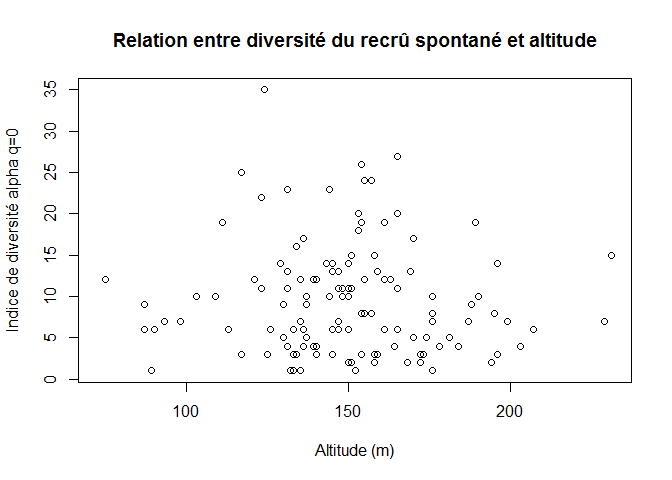

### Pente

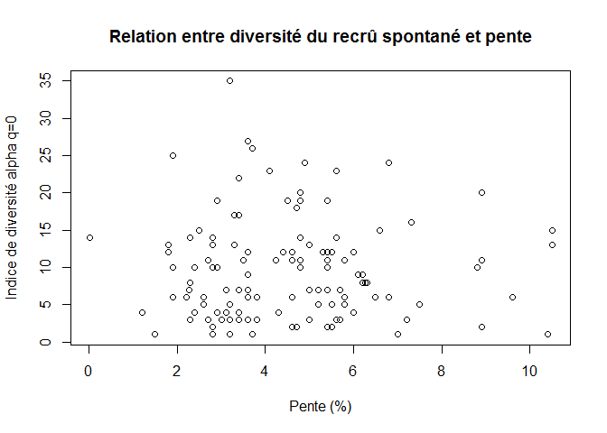

# Conclusion

Les éléments qui ont retenu mon attention:

- la variable “kko” (% de superficie occupée par des cacaoyères dans un rayon de 300m autour de la parcelle inventoriée) semble covarier positivement avec la variable carbone total (carbontot) et la variable diversité alpha d’ordre 0 du recrû spontané (q0alsp).
- la variable “per” (% de superficie occupée par des cultures permanentes (monocultures) dans un rayon de 300m autour de la parcelle inventoriée) semble covarier négativement avec la variable diversité.
- distribution d’apparence normale autour de la variable altitude
- pas d’effet apparent de la pente sur la diversité

# Valeurs d’usage

Méthode: Lors des inventaires botaniques les usages faits des arbres par le propriétaire du champ ont été relevés. Ceux qui sont traités dans cette partie sont les principaux à savoir: alimentaire (domestique et commercial), bois d’oeuvre (domestique et commercial), service agronomique aux cacaoyers (fertilisation, ombrage,…), symbolique (spirituel, beauté, mémoire de pratiques traditionnelles), médicinal, tuteur pour l’igname, fourrage, artisanat et latex.

Ainsi, un Akpi peut être utilisé par un Baoulé comme arbre alimentaire et par un autre planteur comme arbre médicinal et enfin par un troisième comme futur arbre à bois. Ainsi, un même arbre peut avoir différents usages d’une parcelle à l’autre ou cumuler plusieurs usages sur une même parcelle.

Deux valeurs d’usage ont été attribuées aux parcelles:

- une première, appelée “valeur d’usages réels” fait la somme des usages qui sont faits pour chaque arbre. Par exemple un Akpi utilisé par un planteur comme arbre alimentaire et médicinal aurait une note de 2. Ces valeurs sont ensuite additionnées pour obtenir une note à l’échelle de la parcelle. Cette note est ensuite pondérée par la supercifie. On obtient donc un nombre d’usages (correspond donc à la somme des usages/arbres) par hectare. Cette note d’usage réelle reflète les connaissances et les pratiques des producteurs. Elle peut également être déclinée par type d’usage. Par exemple, chaque parcelle peut avoir une valeur correspondant au % d’arbres alimentaires sur le total des usages recensés sur cette même parcelle. Cela permet d’identifier certaines spécialisations.
- La deuxième valeur est appelée “valeur d’usages potentiels”. Elle représente la somme des usages qui pourraient être faits sur une parcelle à partir de tous les usages recensés pour une essence donnée. Par exemple, l’Akpi fait l’objet de 4 usages différents: alimentaire, médicinal, service agronomique aux cacaoyers et bois d’oeuvre. Systèmatiquement, cet arbre a une valeur de 4. Certains producteurs ont des arbres qui peuvent faire l’objet d’usages médicinaux qu’ils ne connaissent pas mais qui sont pratiqués par d’autres producteurs. Cette note de valeur d’usages potentiels reflète la diversité des arbres introduits et peut également être déclinée par type d’usages.

Dans cette partie, les services environnementaux mesurés (carbone et diversité) sont confrontés à ces différents usages. L’objectif étant d’identifier les usages qui permettent de maximiser chacun de ces services et un compromis entre diversité d’usages, biodiversité et stockage de carbone.

Pour l’instant, la méthode est plutôt descriptive et mérite d’être affinée.

## Valeurs d’usages réels (totales et par type d’usages)

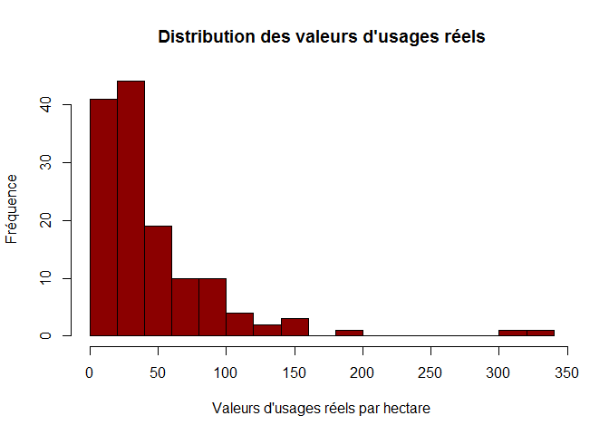

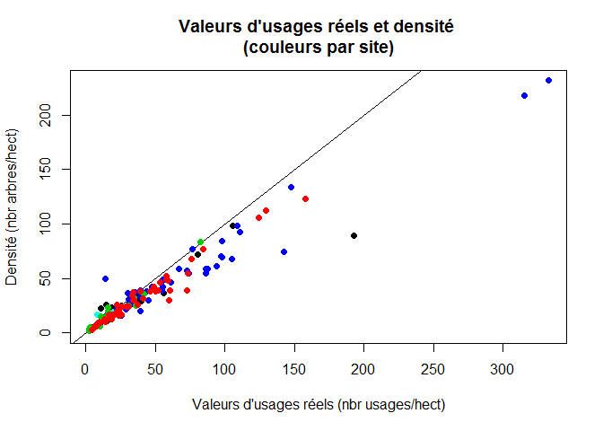

Relation entre diversité et type d’usages (nbr d’arbres/hect):

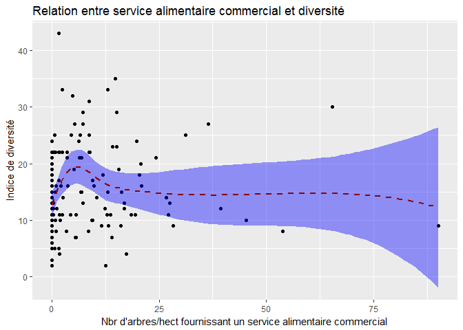

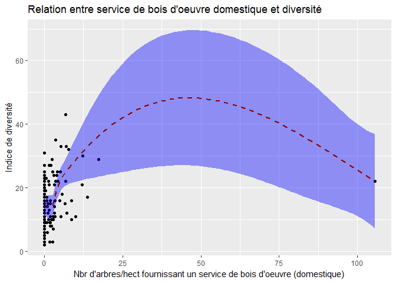

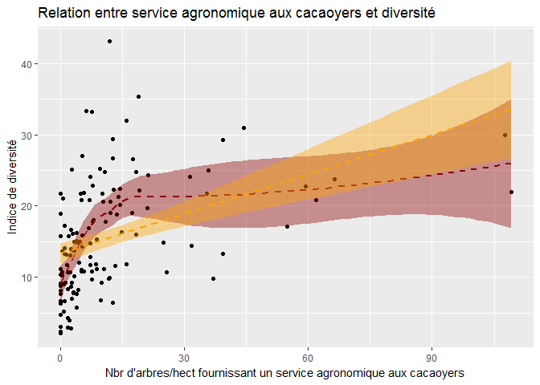

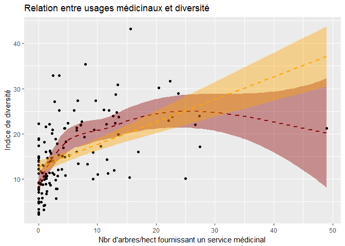

Relation entre diversité et type d’usages (% arbres d’un usage donné sur l’ensemble des arbres):

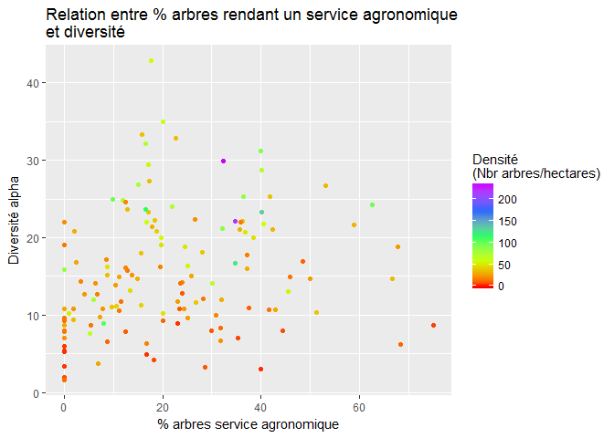

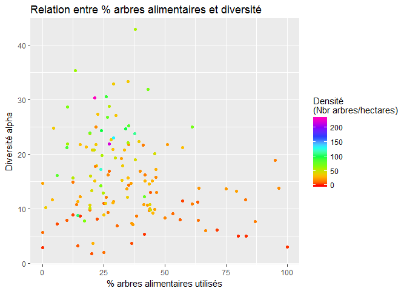

### Quelle est la spécialisation réelle qui maximise la diversité (à l’échelle de la parcelle)?

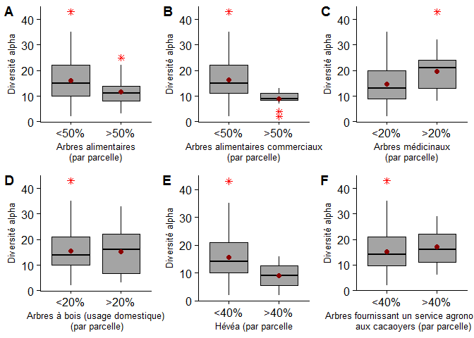

Comparaison des différents usages:

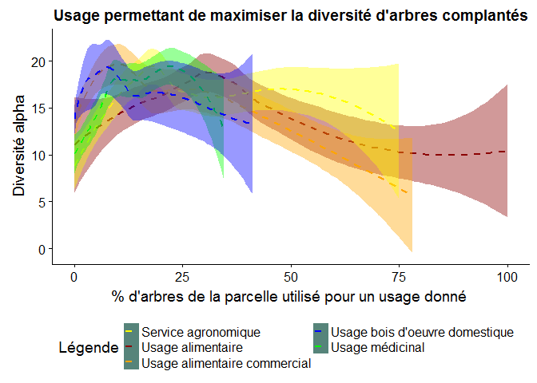

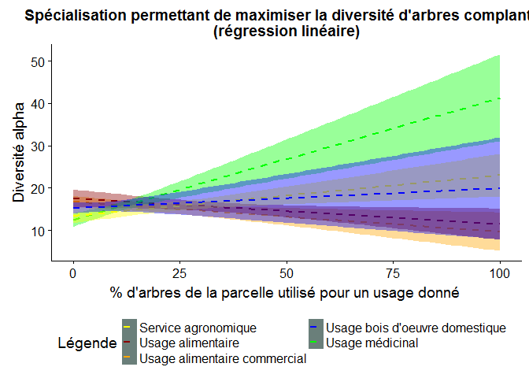

### Quelle est la spécialisation réelle qui maximise le nombre d’arbres/hect (à l’échelle de la parcelle)?

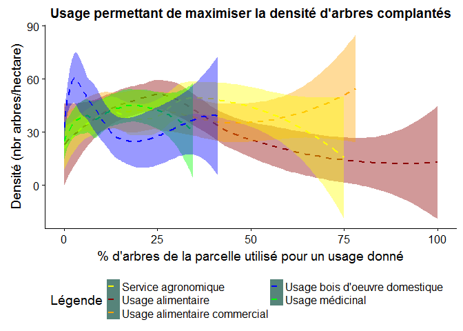

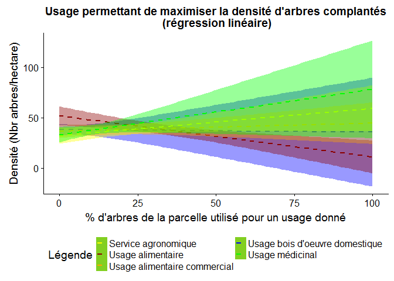

### Quelle est la spécialisation réelle qui maximise la biomasse (à l’échelle de la parcelle)?

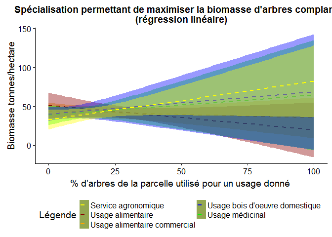

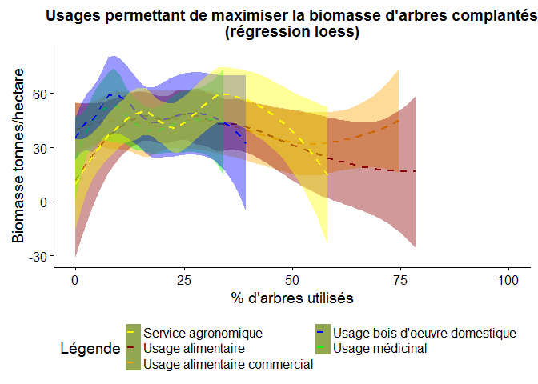

## Identification des arbres multifonctionnels (cumulant plusieurs utilisations possibles)

Les arbres multifonctionnels (au moins deux usages pratiqués sur la même parcelle):

```
##               Genre         Espèce
## 35       Anthonotha       fragrans
## 40        Heritiera         utilis
## 50        Spathodea    campanulata
## 51         Vernonia       colorata
## 53           Acacia        mangium
## 58         Antiaris       africana
## 59    Ricinodendron     heudelotii
## 60            Ficus       capensis
## 61       Anacardium    occidentale
## 63       Artocarpus        altilis
## 64           Persea      americana
## 65          Lophira          alata
## 67       Andansonia       digitata
## 74         Mansonia      altissima
```

[output cut: 65 more lines]

## Valeurs d’usages potentiels

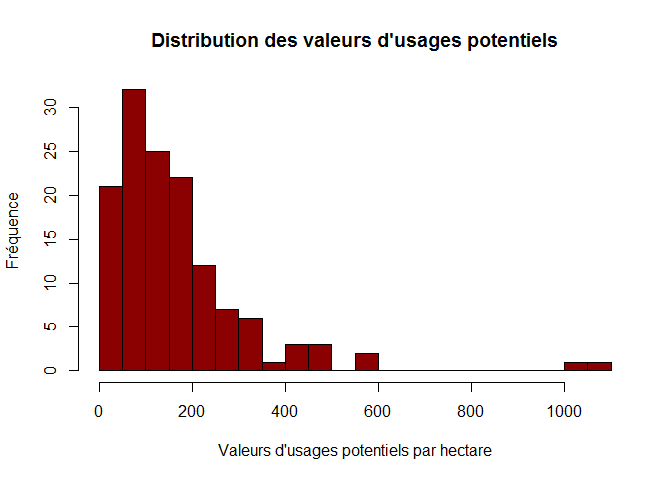

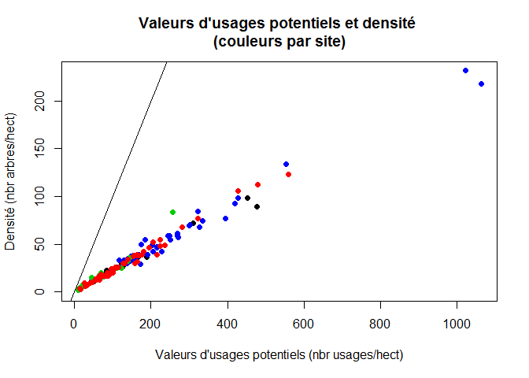

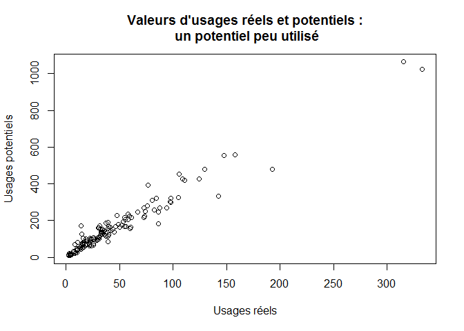

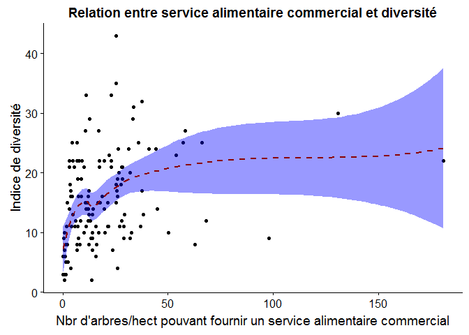

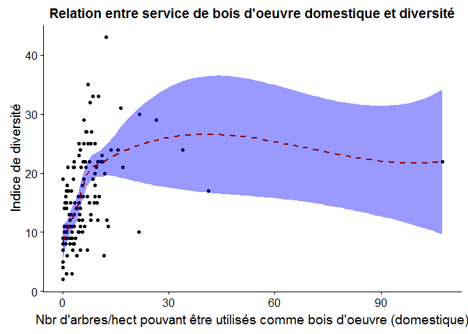

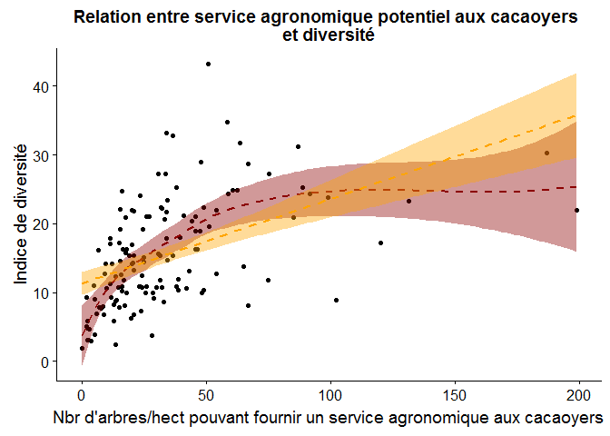

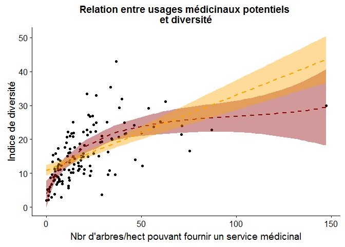

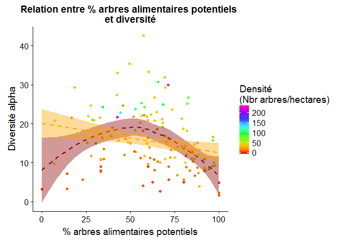

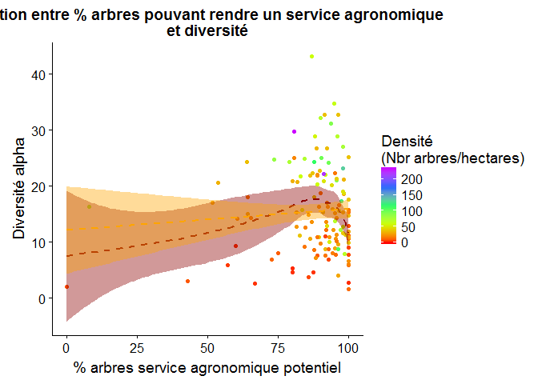

### Quelle est la spécialisation potentielle qui pourrait maximiser la diversité (à l’échelle de la parcelle)?

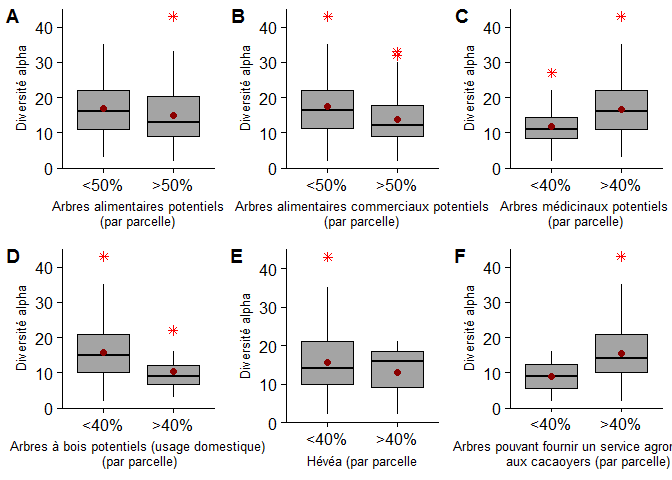

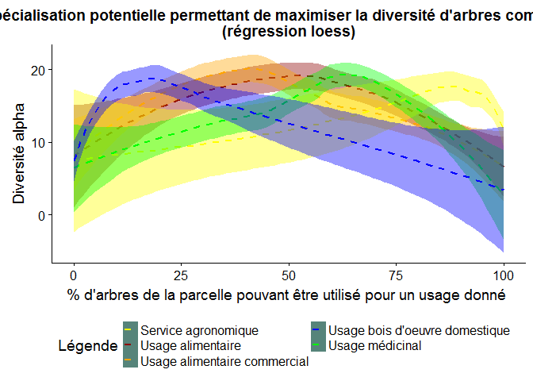

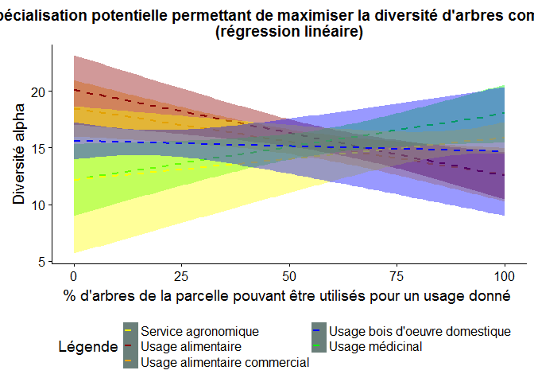

### Quelle est la spécialisation potentielle qui pourrait maximiser le nombre d’arbres/hect?

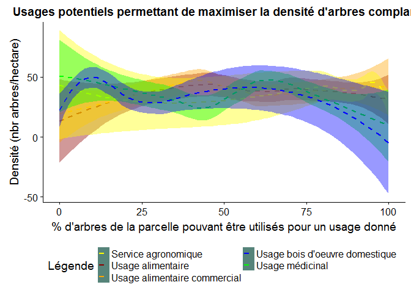

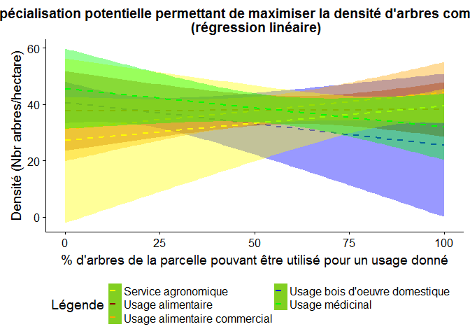

### Quelle est la spécialisation potentielle qui pourrait maximiser la biomasse (à l’échelle de la parcelle)?

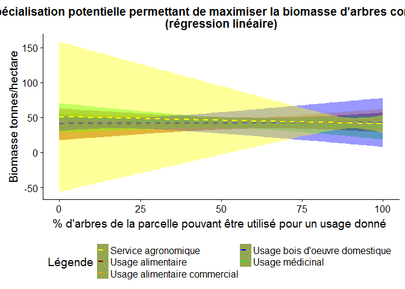

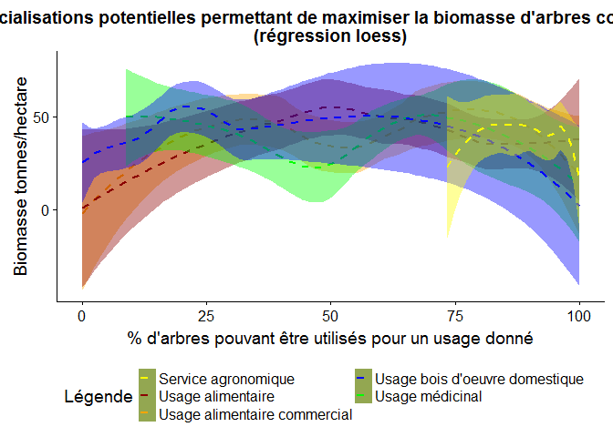

# Conclusion

Ces analyses doivent maintenant être incluses dans des approches multivariées plus fidèles à la réalité. En effet, il y a deux limites à ces graphiques:

- régression de loess: très fluctuantes et peu lisibles
- régression linéaire : elles tendent vers l’infini ce qui n’est pas réaliste et elles ont des intervals de confiance très étendu, témoignant d’une inadéquation du modèle au phénomène.

Il faudrait également pondérer ces analyses par la densité. Ex: une parcelle avec seulement 3 arbres/hectare qui sont 3 arbres à bois va présenter 100% d’arbres à bois mais une très faible diversité. Ainsi, elle introduit un biais dans l’analyse. Cette parcelle existe et explique la chute de la courbe de loess représentant l’usage bois d’oeuvre sur le graphique diversité.